# 2026年05月05日 研究日志

今日主题：汇总bulk-RNA seq数据集GSE91087的样本情况。该数据集使用的是来自4位捐献者（低风险组2人，高风险组2人）的成纤维细胞，通过诱导细胞多样性得到的**6**个iPSC-RPE样本。

本文作为一篇2017年的文献，对于iPSC的操作较为简单,：

> We have derived and characterized induced pluripotent stem cell (iPSC) lines from two subjects without AMD and low-risk genotype and two patients with advanced AMD and high-risk genotype and generated RPE cells that show local secretion of several proteins involved in the complement pathway including factor H, factor I, and factor H-like protein 1.

该研究的样本情况如下：

| Sample Name | Condition | read length | Raw_reads (pair) | QC_reads (pair) | Uniquely-mapping rate | Multiple-mapping rate | Transcriptome Mapped (pair) | Transcriptome mapping rate | Transcriptome mapping rate (of total mapped reads) | mean gene count (GENCODE V24) |
| --- | --- | --- | --- | --- | --- | --- | --- | --- | --- | --- |
| 13-2-1 | low risk | 76 | 35738092 | 34976571 | 92.03% | 6.89% | 27379615 | 0.78 | 0.77 | 413.6 |
| 13-2-2 | low risk | 76 | 26169310 | 25598419 | 92.18% | 6.74% | 20248094 | 0.79 | 0.77 | 305.8 |
| 13-2-3 | low risk | 76 | 41139891 | 40294999 | 92.15% | 6.84% | 32024001 | 0.79 | 0.78 | 483.7 |
| 18-2-1 | high risk | 76 | 16986420 | 16592025 | 90.19% | 8.50% | 12814630 | 0.77 | 0.75 | 193.6 |
| 18-2-2 | high risk | 76 | 35819985 | 35042554 | 90.99% | 7.87% | 27532747 | 0.79 | 0.77 | 415.9 |
| 18-2-3 | high risk | 76 | 29391757 | 28736199 | 90.15% | 8.58% | 21921996 | 0.76 | 0.75 | 331.1 |

说真的只有6个样本的bulk-RNA seq做差异表达分析真的正确吗……事实上该研究明显采用了一种不太常规的DE统计阈值：选择位于99.73百分位的基因，即表达水平在均值±3个标准差（μ±3σ）之外，对应≥5倍或≤-5倍的表达变化。我对此持保留意见，但还是对数据进行了差异表达分析并绘制了火山图：

```r
suppressPackageStartupMessages({
    library(here)
    library(tidyverse)
    library(ggrepel)
})
```

```r
load("./data/GSE91087.Rdata")
```

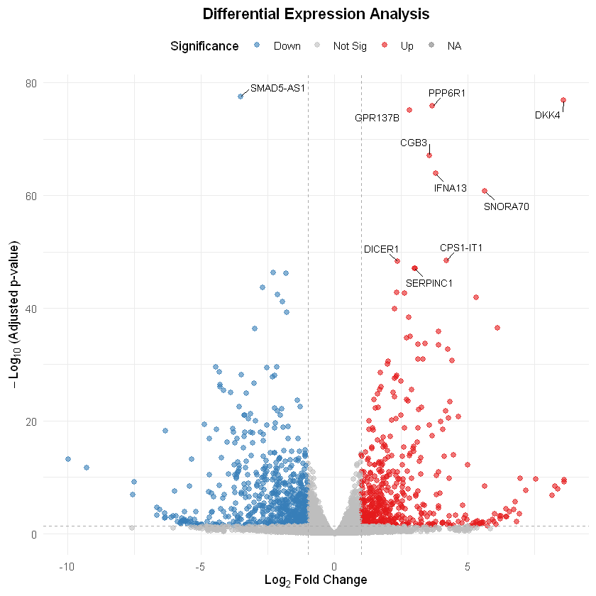

```r
Volcano_plot
```

仅有6个样本的数据集很难将其视作足够有统计效果的结果，但其提供了一个很好的起点：

1. 通过诱导多能干细胞（iPSC）技术，从携带补体因子H（CFH）Y402H高风险基因型的AMD患者和低风险对照个体中建立了视网膜色素上皮（RPE）细胞模型。该模型能够模拟AMD的关键病理特征，包括：
- 炎症与应激增加：高风险iPSC-RPE细胞中炎症因子（如IL1β）表达上调，抗氧化基因（如SOD2）表达降低。
- 脂代谢异常：高风险细胞积累更大的脂滴和类玻璃膜疣沉积，且ApoE与C5b-9共定位的沉积物体积显著增加。
- 自噬功能受损：高风险RPE细胞中LC3 puncta和p62 aggregates数量显著增加，提示自噬通路受阻。
- 超微结构改变：包括微绒毛缩短、线粒体数量减少但体积增大，以及应激性空泡形成。
2. RPE细胞的局部补体调节作用 研究证实iPSC-RPE细胞可自主分泌补体系统关键蛋白（如**FH**、**FHL-1**、**FI**、**C3**），并通过功能实验证明其能够介导**C3b**的降解。高风险RPE细胞中CFH、FHL-1和CFI的表达上调，而C3表达下调，提示局部补体激活在AMD病理中起重要作用。
3. UV光暴露对AMD-RPE的差异化影响 虽然着并非我的研究的重点，但这一发现可能同样具有启发意义：间歇性UV（390-410 nm）暴露对低风险和高风险RPE细胞产生不同效应
- 高风险细胞：SOD2、CFH和FHL-1表达上调，微绒毛长度增加，空泡数量和类玻璃膜疣体积减少，细胞功能和结构得到改善。
- 低风险细胞：仅IL6和CFI表达增加，未观察到结构或功能的显著变化。

## 总结：该iPSC-RPE模型为AMD研究提供了一种可选的工具，可用于：

- 解析补体激活、氧化应激等病理机制。
- 筛选潜在治疗药物（如补体调节剂）。
- 评估环境因素（如UV暴露）对疾病的影响。

# Reference

Hallam, D., Collin, J., Bojic, S., Chichagova, V., Buskin, A., Xu, Y., Lafage, L., Otten, E. G., Anyfantis, G., Mellough, C., Przyborski, S., Alharthi, S., Korolchuk, V., Lotery, A., Saretzki, G., McKibbin, M., Armstrong, L., Steel, D., Kavanagh, D., & Lako, M. (2017). An Induced Pluripotent Stem Cell Patient Specific Model of Complement Factor H (Y402H) Polymorphism Displays Characteristic Features of Age-Related Macular Degeneration and Indicates a Beneficial Role for UV Light Exposure. Stem Cells, 35(11), 2305–2320. https://doi.org/10.1002/STEM.2708